# Morphometric Variations in Australian Possums

Winter 2019

## Data Set Background

The possum data frame consists of nine morphometric measurements on 104 mountain brushtail possums, trapped at seven sites from Southern Victoria to central Queensland. In 2002, they were proposed to be reclassified into two separate species: the mountain brushtail and short-eared.

Source  
> Lindenmayer, D. B., Viggers, K. L., Cunningham, R. B., and Donnelly, C. F. 1995. Morphological variation among columns of the mountain brushtail possum, Trichosurus caninus Ogilby (Phalangeridae: Marsupiala). Australian Journal of Zoology 43: 449-458.  
> URL: https://vincentarelbundock.github.io/Rdatasets/datasets.html

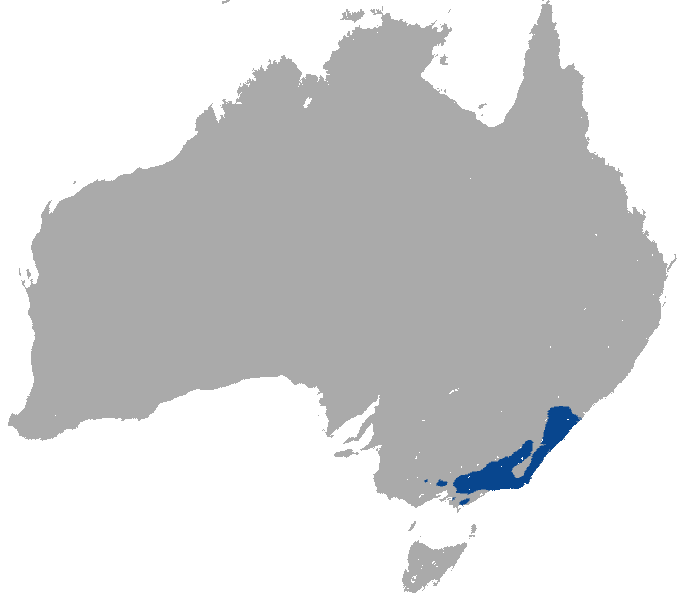

## Loading the Libraries and Reading the Data

library(tidyverse)  
library(skimr)  
library("RColorBrewer")

possum <- readr::read_csv(file = "possum.csv", na = c("", " ", "NA", "#N/A", "-999", "\"))

## Overview of Data

Check dimensions  
dim(possum)

```
## [1] 104  15
```

Check column names colnames(possum)

```
##  [1] "X1"       "case"     "site"     "Pop"      "sex"      "age"
##  [7] "hdlngth"  "skullw"   "totlngth" "taill"    "footlgth" "earconch"
## [13] "eye"      "chest"    "belly"
```

```
## Skim summary statistics
##  n obs: 104
##  n variables: 15
##
## -- Variable type:character -------------------
##  variable missing complete   n min max empty n_unique
##       Pop       0      104 104   3   5     0        2
##       sex       0      104 104   1   1     0        2
##        X1       0      104 104   2   5     0      104
##
## -- Variable type:numeric ---------------------
##  variable missing complete   n  mean    sd   p0   p25   p50   p75  p100
##       age       2      102 104  3.83  1.91  1    2.25  3     5      9
##     belly       0      104 104 32.59  2.76 25   31    32.5  34.12  40
##      case       0      104 104 52.5  30.17  1   26.75 52.5  78.25 104
##     chest       0      104 104 27     2.05 22   25.5  27    28     32
##  earconch       0      104 104 48.13  4.11 40.3 44.8  46.8  52     56.2
##       eye       0      104 104 15.05  1.05 12.8 14.4  14.9  15.72  17.8
##  footlgth       1      103 104 68.46  4.4  60.3 64.6  68    72.5   77.9
##   hdlngth       0      104 104 92.6   3.57 82.5 90.68 92.8  94.73 103.1
##      site       0      104 104  3.62  2.35  1    1     3     6      7
##    skullw       0      104 104 56.88  3.11 50   54.98 56.35 58.1   68.6
##     taill       0      104 104 37.01  1.96 32   35.88 37    38     43
##  totlngth       0      104 104 87.09  4.31 75   84    88    90     96.5
##      hist
##  ▇▇▅▃▃▂▁▁
##  ▁▂▃▇▇▆▁▁
##  ▇▇▇▇▇▇▇▇
##  ▂▂▆▇▇▅▂▁
##  ▁▅▇▃▁▆▅▁
##  ▂▂▆▇▃▃▁▁
##  ▂▇▇▅▅▇▃▁
##  ▁▂▃▇▇▃▁▁
##  ▇▃▂▂▁▃▃▅
##  ▁▃▇▆▂▁▁▁
##  ▁▂▇▆▇▃▁▁
##  ▁▁▅▆▃▇▃▁
```

## Renaming variables for consistency

possum <- possum%>%  
dplyr::rename(  
pop = Pop, #population  
foot = footlgth, #foot length  
head = hdlngth, #head length  
skull = skullw, #skull width  
tail = taill, #tail length  
tooth = totlngth #tooth length  
)

## Dataset Cleaning-Up

This data frame is not tidy, because the first column does not have a column name (it got assigned X1 as its name automatically by R).

How to change that:

Rename X1 into sample  
colnames(possum)<-c("sample","case","site","pop", "sex","age","head","skull","tooth","tail","foot","earconch","eye","chest","belly")

We've also noticed that the columns are variables, so that would need to be addressed later on when we start using the data to make visualizations.

## Identifying the NA's

Which column has the most NA's?

```
## # A tibble: 15 x 2
##    variables num_nas
##    <chr>       <int>
##  1 age             2
##  2 foot            1
##  3 sample          0
##  4 case            0
##  5 site            0
##  6 pop             0
##  7 sex             0
##  8 head            0
##  9 skull           0
## 10 tooth           0
## 11 tail            0
## 12 earconch        0
## 13 eye             0
## 14 chest           0
## 15 belly           0
```

## Research Topic

In 2002, it was proposed that the mountain brushtail possum be reclassified into two distinct species: the northern short-eared possum and the southern mountain brushtail possum.

Can this dataset justify separating the possum into two species by morphometrics?

## Main Question 1

### Is there a difference in possum morphology between populations in Victoria (the south) and populations outside of Victoria (the north)?

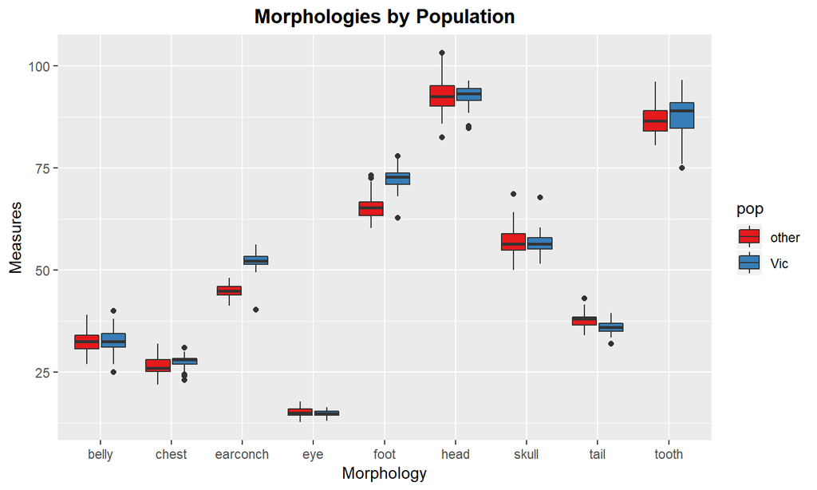

We expected a difference in earconch lengths since it is the defining morphological difference between the two proposed species of possums.

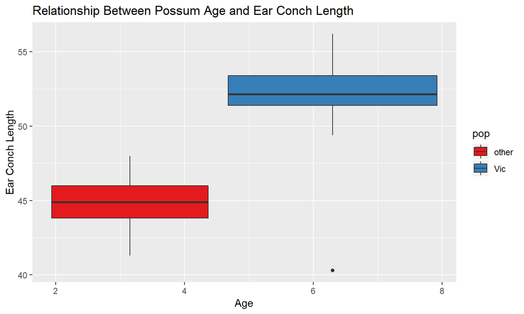

## Sub Question 2

### Correlation between age and ear conch length?

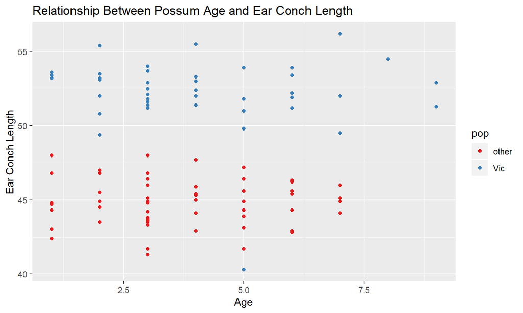

No correlation between age and ear conch length. The difference in ear conch leangth is very likely to be determined solely by the population that they belong to.

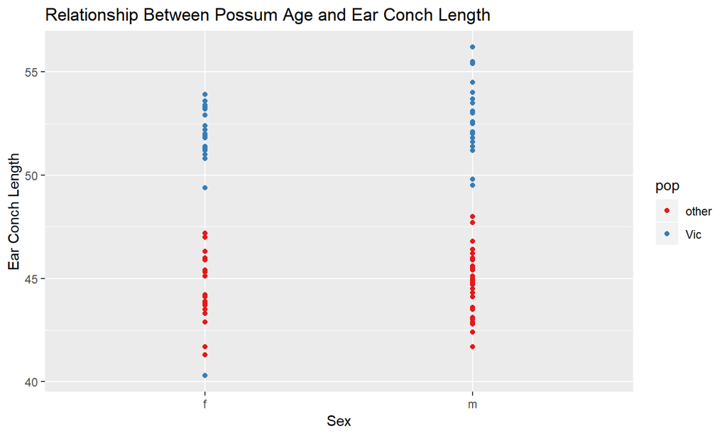

No correlation between sex and ear conch length. Males and females of the same population display similar ear conch length. The difference in ear conch leangth is very likely to be determined solely by the population that they belong to.

## Main Question 2

The mountain brushtail possum shows little sexual dimorphism, meaning that the females and males of this species show little distinct characteristics beyond their sexual organs.

Examine if it is true that the two populations of possum show little sexual dimorphism.

## Sub Question 1

What is the count of females and males in both populations?

## Count of Possums by Sex in Victoria

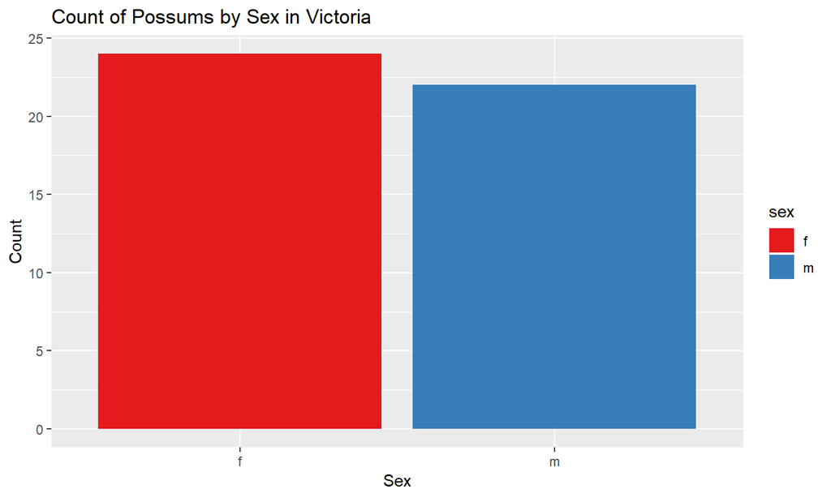

We can see that there is a relatively equal ratio of female to male in the mountain bushtail possums of Victoria.

## Count of Possums by Sex in Others

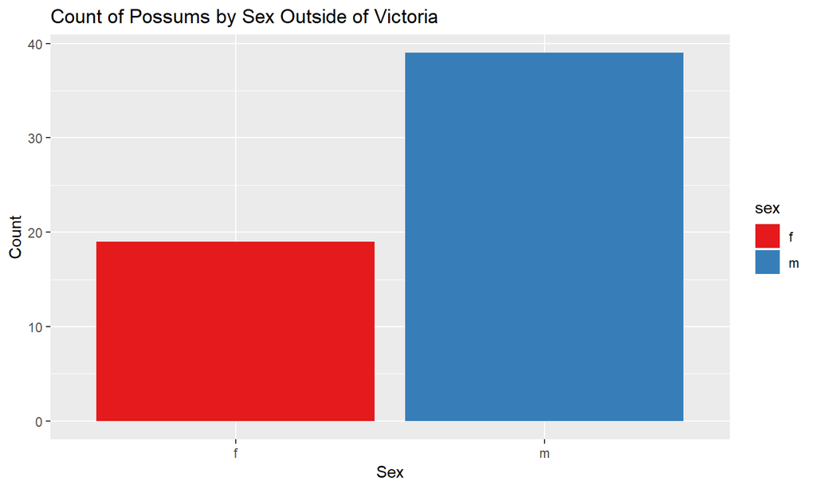

## Compare relative densities of sex by population

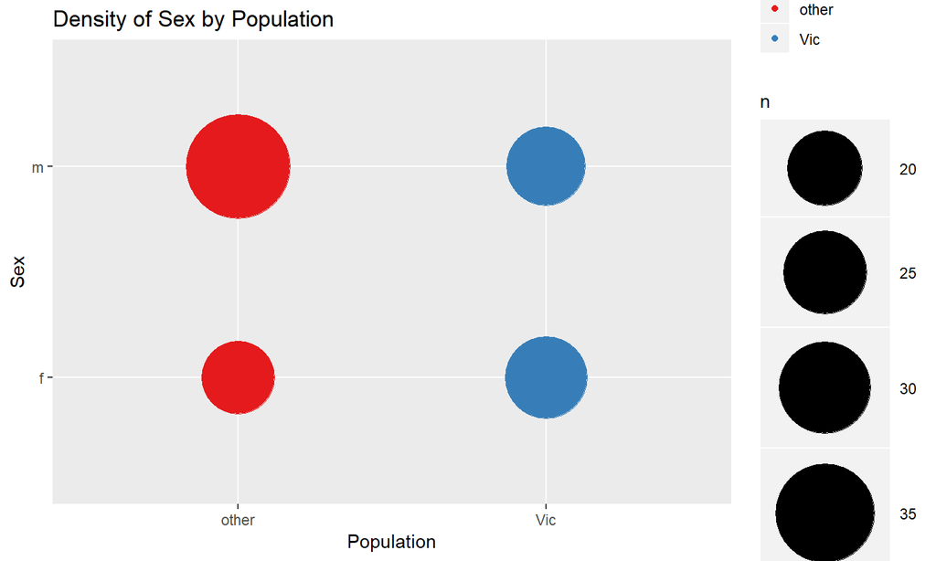

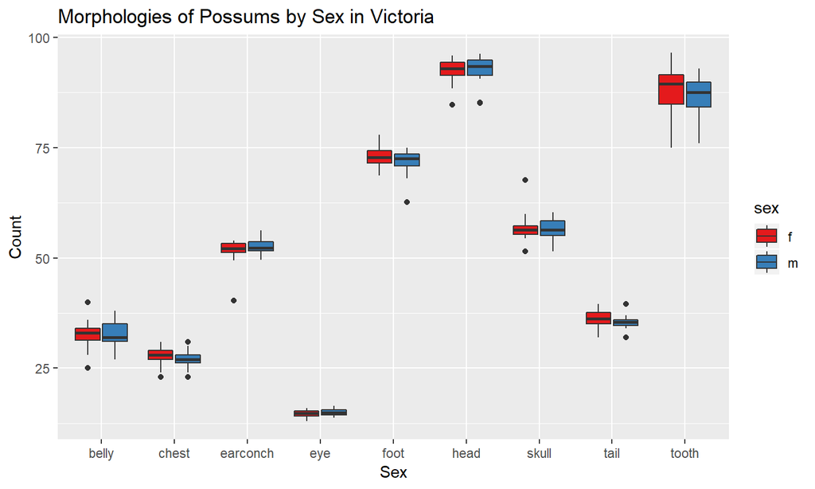

Female and male mountain brushtail possums in Victoria have similar ranges of morphological characteristics, furthering how this particular species display little sexual dimorphism.

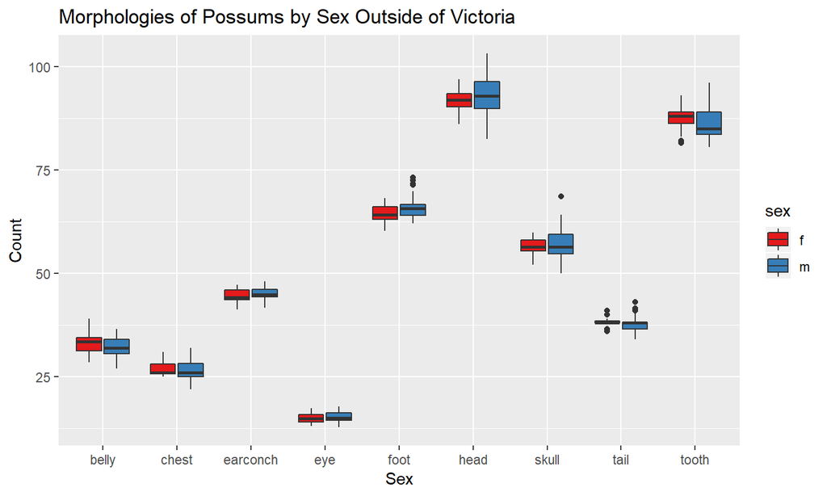

The males of the short-eared possums population outside of Victoria display a wider range of morphological characteristics than females.

## Conclusion

In conclusion, we agree with the justifications for splitting the possums into two separate species.

Both species show morphologial difference, especially in regards to earconch length and feet length.

The species from the south, the mountain brushtail possums, show little sexual dimorphism; the species from the north, the short-eared possums, have males that are more varied in size and shape than females.

The ratio of male to female is closer to 1:1 in the mountain brushtail possums, indicating a monogamous population; the ratio of male to female is almost 2:1 in the short-eared possums, indicating a polygynous population; this also might suggest a difference in gene between the two populations.

## Mountain Brushtail Possum

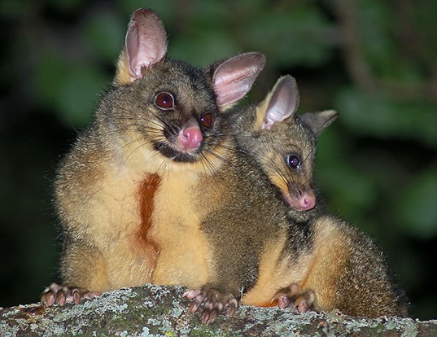

## Short-eared Possum

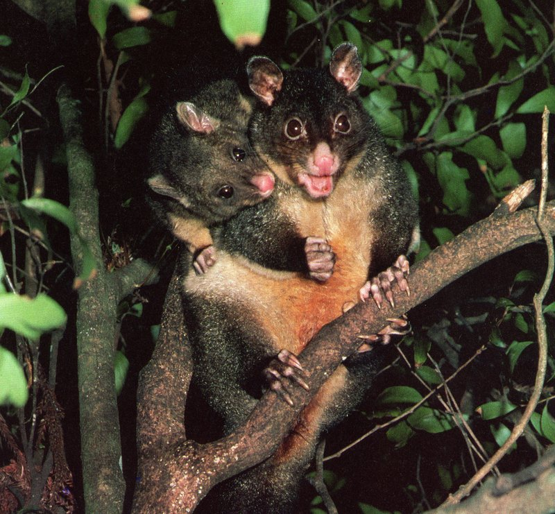

## Additional Information & Research

*Australian museum* https://australianmuseum.net.au/learn/animals/mammals/mammology-collection-mountain-brushtail-possum/  
*Geographic dimorphism in the mountain brushtail possum (Trichosurus caninus): The case for a new species* https://www.researchgate.net/publication/240510066_Geographic_dimorphism_in_the_mountain_brushtail_possum_Trichosurus_caninus_The_case_for_a_new_species

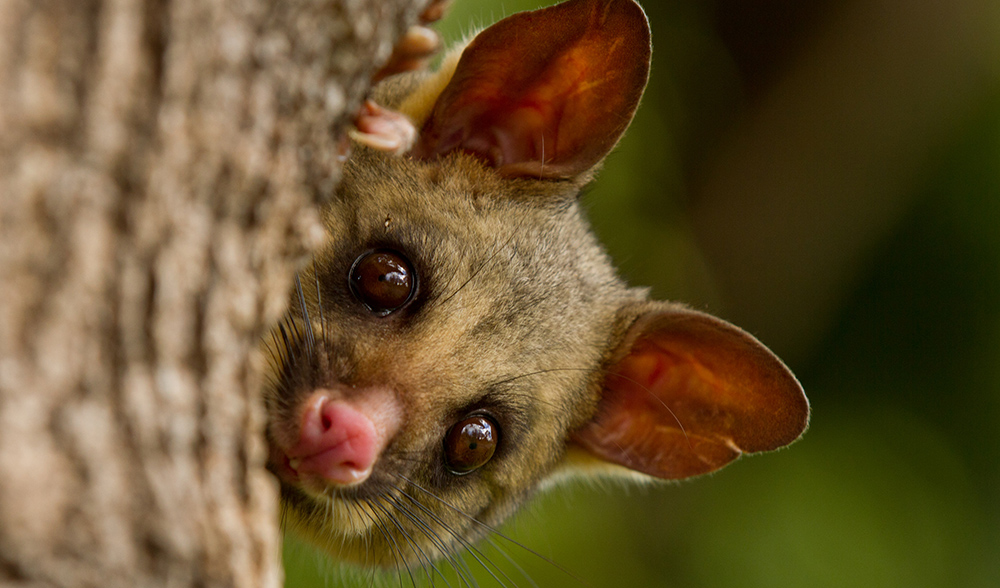